# Ford GoBike Data Exploration

### What is the structure of your dataset?

There are 174,952 customers in the data set with their age, gender, flights, duration and stations used.

### What is/are the main feature(s) of interest in your dataset?

I am interested in investigate duration of biking time.

### What features in the dataset do you think will help support your investigation into your feature(s) of interest?

I think features start_time, birth_year, gender, and user_type may help to support my investigation into the feature (duration).

## Univariate Exploration

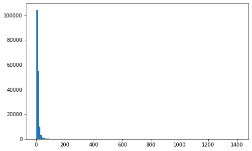

##### It's seems that most data are below 200. Let's find out the distribution.

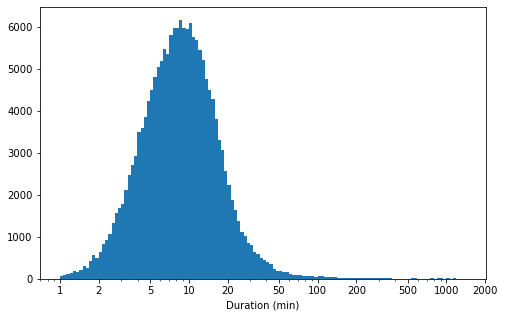

##### The distribution now looks closer to normal distribution. But, there is a long tail still. Let's remove the long tail.

##### Looks like it's going to take a minute to an hour and a third.

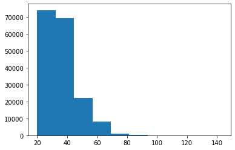

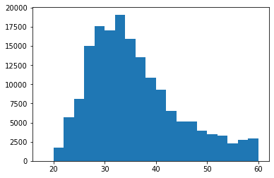

##### The most age-riding score is ranging 20 : 60 years.

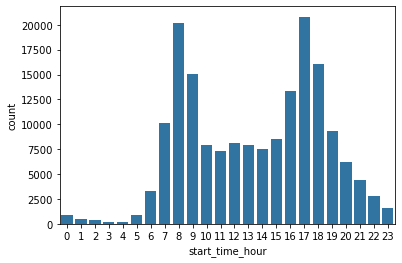

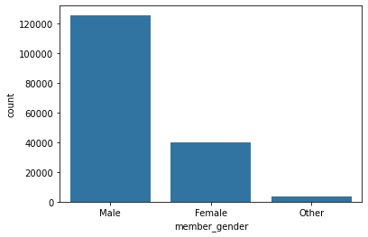

##### Men are more used to bike than ladies

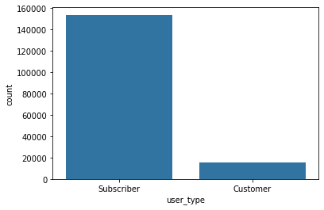

##### Subscribers are more request after than other customers

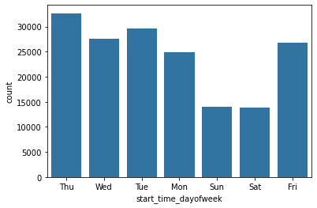

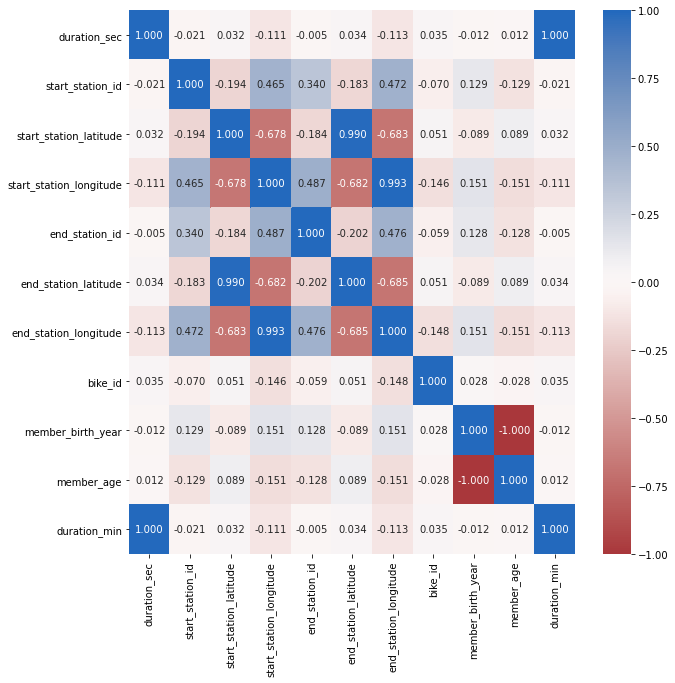

##### The correlation cofficients indicate there might be correlations between the following pairs of variables: (start_station_id, end_station_id), (start_station_latitude, start_station_longitude), and (end_station_latitude, end_station_longitude). However, there are no strong evidences to support these. So these might happen just by accident.

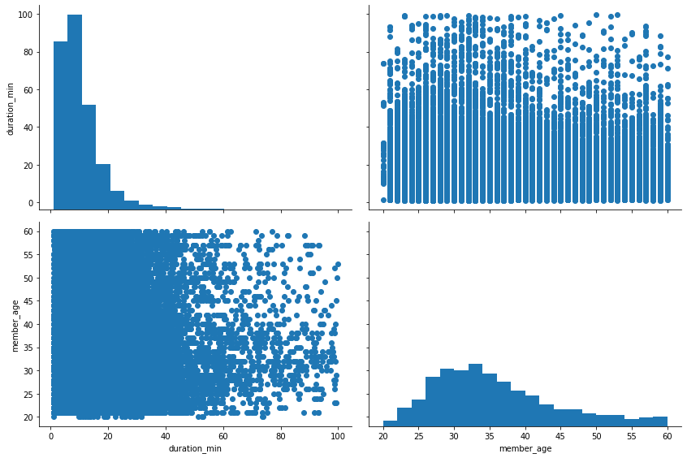

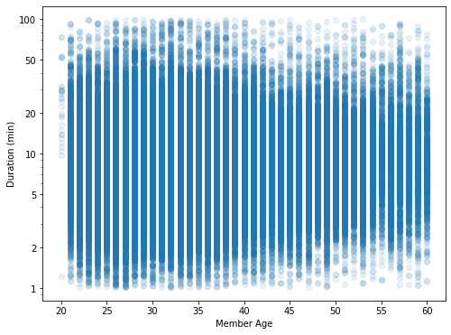

##### Although we are still not seeing linear relationship between duration_min and member_age, the data looks distribute more even compared to the scatter plot drawn eariler.

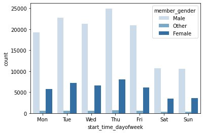

##### It seems that males are always more riding grades than females throughout the week.

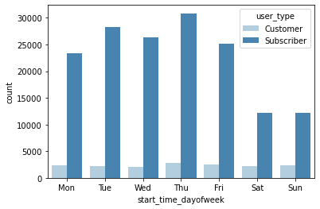

##### It seems that the Subscriber are always more riding the score throughout the week.

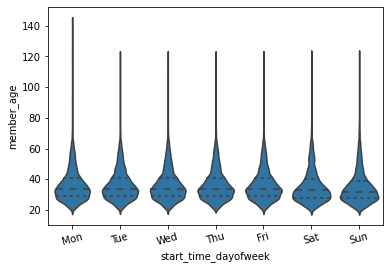

##### On average, all days seem to be equal in age, but on Monday, the oldest age is recorded.

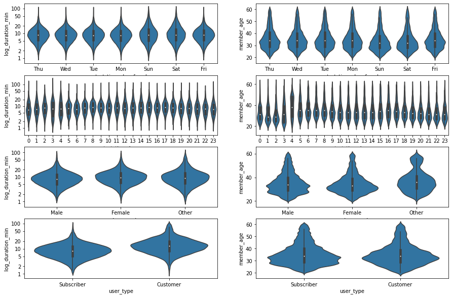

- The shapes of the violins in the plots on the left side (with 'log_duration_min' as y-axis) are more even compared to the shapes of the violins in the plots on the right side (with member_age as y-axis). The transformation make the violins on the left side looks more even.
- Look at the plot on 1st row, 1st column: there are more bike rides with durations close to mean duration time (10 minutes) on the weekdays compared to the bike rides on the weekends.
- Look at the plot on 3rd row, 1st column: the mean bike duration for female biker is longer than the the mean duration of the male bikers.
- Look at the plot on 4th row, 1st column: the mean bike duration for 'Customer' biker is longer than the the mean duration of the 'Subscriber' bikers.